# Evaluate Model Fit

## Today’s Learning Goals

- Interpret estimates for continuous and binary predictors.
- Explain confidence intervals and statistical significance correctly.
- Compare models using \(R^2\).
- Generate customer-profile predictions with prediction intervals.
- Explain what model fit and uncertainty mean for a business decision.

## Inferential Modeling Workflow

**Build → Fit → Evaluate → Predict**

Last class, we **built** and **fit** a model of customer spending. Today we will **evaluate** the model and (and compare it to alternatives) use the model to generate **predictions**.

- **Evaluate:** how useful and precise are the estimated relationships?
- **Predict:** what spending does the model imply for a customer profile, and how uncertain is an individual outcome?

## Evaluate

### Planning Customer Outreach

The home-goods retailer is developing customer segments for outreach. It wants to understand which household profiles tend to spend more and how much spending varies within a profile.

## Getting Started

We’re going to analyze the same customer records as last time.

```r
library(tidyverse)
library(tidymodels)

customers <- read_csv("home_goods_customers.csv", show_col_types = FALSE)
```

## Cleaning Up the Data

- `PreviousSpend`: dollars spent at this retailer in the previous 12 months.
- `IncomeThousands`: annual household income divided by 1,000.
- `Homeowner`: 1 = owns the primary residence; 0 = does not own.

```r
customer_model_data <- customers |>
  drop_na(HouseholdIncome, Homeowner, PreviousSpend) |>
  mutate(IncomeThousands = HouseholdIncome / 1000)

nrow(customer_model_data)
```

```
## [1] 9800
```

We use the same **9,800 customers** as last time.

## Fit the Income Model

Refit the `income` model from last lecture:

```r
fit_income <- linear_reg() |>
  set_engine("lm") |>
  fit(PreviousSpend ~ IncomeThousands, data = customer_model_data)
```

```r
tidy(fit_income)
```

```
## # A tibble: 2 × 5
##   term            estimate std.error statistic p.value
##   <chr>              <dbl>     <dbl>     <dbl>   <dbl>
## 1 (Intercept)       760.      3.45       220.        0
## 2 IncomeThousands     2.57    0.0322      79.8       0
```

## Evaluate: Interpreting a Continuous Predictor

For a model with one continuous predictor:

\[\hat{y} = \beta_0 + \beta_1 x\]

- **Slope (\(\beta_1\)):** a one-unit increase in \(x\) is associated with a \(\beta_1\)-unit difference in \(y\).
- **Intercept (\(\beta_0\)):** the predicted mean of \(y\) when \(x = 0\); interpret it in context only if zero is meaningful and within the relevant range of the original data.
- In a model with multiple predictors, interpret each slope **holding the other included predictors fixed**.

## Interpret IncomeThousands

### Customer Spending

\[\widehat{PreviousSpend} = 760.42 + 2.57 \times IncomeThousands\]

- **Slope:** another $1,000 of annual household income is associated with about $2.57 more spending at this retailer over 12 months.
- **Intercept:** predicted spending at zero income; zero is outside the observed $15,000–$350,000 income range.

## What about a Binary Predictor?

A **binary** predictor has two levels. In this case, `Homeowner` is 0 or 1.

```r
fit_owner <- linear_reg() |>
  set_engine("lm") |>
  fit(PreviousSpend ~ Homeowner, data = customer_model_data)
```

```r
tidy(fit_owner)
```

```
## # A tibble: 2 × 5
##   term        estimate std.error statistic   p.value
##   <chr>          <dbl>     <dbl>     <dbl>     <dbl>
## 1 (Intercept)     921.      3.65     252.  0
## 2 Homeowner       119.      4.51      26.3 7.50e-148
```

## Interpret a Binary Predictor

For a model with one predictor coded \(x = 0\) or \(x = 1\):

\[\hat{y} = \beta_0 + \beta_1 x\]

- **Reference group (\(x = 0\)):** predicted mean \(y\) is \(\beta_0\).
- **Comparison group (\(x = 1\)):** predicted mean \(y\) is \(\beta_0 + \beta_1\).
- **Slope (\(\beta_1\)):** the predicted mean difference, **group 1 minus group 0**, in \(y\)’s units.

In a model with multiple predictors, compare the groups **holding the other included predictors fixed**.

## Interpret Homeowner

### Customer Spending

\[\widehat{PreviousSpend} = 921.12 + 118.81 \times Homeowner\]

- **Intercept:** estimated mean past spending for customers who do not own their primary residence, about $921.12.
- **Slope:** owners spent about $118.81 more on average than nonowners in this model.
- For owners, predicted spending is $921.12 + $118.81 = **$1,039.93**.

Remember, this **does not** establish that owning a home causes extra purchases.

## How do I Know the Model Results are ‘Real’?

**Manager**:

“Okay you found that on average, homeowners spend about $118 more than non-homeowners. How do I know I can trust it?”

## Handling Model Uncertainty

Key Question: Assume that there is no relationship between owning a home and customer spend. Then, how likely is it that our model produces an estimate at least as large as the one we saw?

## Handling Model Uncertainty

Key Question: Assume that there is no relationship between owning a home and customer spend. Then, how likely is it that our model produces an estimate at least as large as the one we saw?

**A *p*-value answers this question!**

Example: imagine your model reports a *p*-value of 0.30 for \(\beta_1 = 1.25\). Then, *the probability* that your model would estimate \(\beta_1 \ge 1.25\) (or \(\beta_1 \le -1.25\)) when \(\beta_1\) **is actually 0** is equal to 30%.

We typically look for the probability to be 5% or less (*p*-value \(\le 0.05\)) before claiming “statistical significance”.

## Home Ownership *p*-value

What is the \(p\)-value? What does it imply about our model estimate?

```r
tidy(fit_owner)
```

```
## # A tibble: 2 × 5
##   term        estimate std.error statistic   p.value
##   <chr>          <dbl>     <dbl>     <dbl>     <dbl>
## 1 (Intercept)     921.      3.65     252.  0
## 2 Homeowner       119.      4.51      26.3 7.50e-148
```

## *p*-values Aren’t Very ‘Interpretable’

Manager:

“You’ve established that there is likely a relationship between home ownership and spending. But what if the true effect is only $10? We wouldn’t bother targeting that demographic if the true effect is really small.”

## Enter: The Confidence Interval!

A **confidence interval** quantifies the uncertainty around a model coefficient.

```r
tidy(fit_owner, conf.int = TRUE)
```

```
## # A tibble: 2 × 7
##   term        estimate std.error statistic   p.value conf.low conf.high
##   <chr>          <dbl>     <dbl>     <dbl>     <dbl>    <dbl>     <dbl>
## 1 (Intercept)     921.      3.65     252.  0             914.      928.
## 2 Homeowner       119.      4.51      26.3 7.50e-148     110.      128.
```

For the effect of home ownership on spending, the 95% interval is approximately **$110 - $128**.

## Reporting Confidence Interval Results

You:

“I am 95% confident that the true effect of home ownership on spending is between **$110** and **$128**. We can’t establish that home ownership *causes* more spending, but these results establish that home owners spend significantly more than non-homeowners, on average.”

## What Does 95% Mean?

Under the model assumptions, about **95% of intervals constructed from repeated samples** would contain the true coefficient.

- The coefficient is fixed; the interval changes with the sample.
- The 95% refers to the procedure’s coverage, not a probability assigned to the fixed coefficient or a range for 95% of customers.

## Repeating the Study

### 100 Hypothetical Samples

For this illustration only, suppose the **true homeowner coefficient is $120**. Collect 100 hypothetical samples of 200 customers, refit the spending model each time, and calculate a 95% confidence interval.

| Sample | β₁ estimate | Lower 95% | Upper 95% | Contains 120? |
| --- | --- | --- | --- | --- |
| 1 | 164.49 | 105.62 | 223.36 | Yes |
| 2 | 88.74 | 28.16 | 149.31 | Yes |
| 3 | 49.03 | -11.70 | 109.75 | No |
| 4 | 151.71 | 91.72 | 211.69 | Yes |
| 5 | 70.29 | 5.45 | 135.13 | Yes |
| 7 | 186.93 | 122.82 | 251.04 | No |

All coefficient values are in dollars. These rows include intervals that contain the true value and intervals that miss it. The true coefficient stays fixed; estimates and intervals change.

## Which Intervals Contain the True Coefficient?

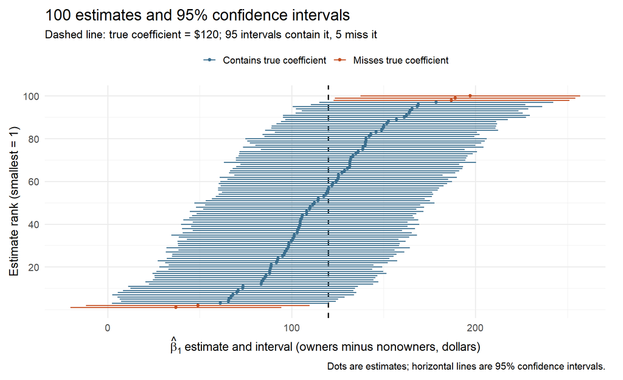

**This run has 95 intervals covering the true coefficient. Another 100 samples could give a different count.** The 95% describes long-run coverage under the model assumptions.

## Apply Confidence Intervals

### Income

```r
tidy(fit_income, conf.int = TRUE)
```

```
## # A tibble: 2 × 7
##   term            estimate std.error statistic p.value conf.low conf.high
##   <chr>              <dbl>     <dbl>     <dbl>   <dbl>    <dbl>     <dbl>
## 1 (Intercept)       760.      3.45       220.        0   754.      767.
## 2 IncomeThousands     2.57    0.0322      79.8       0     2.51      2.63
```

The income slope’s 95% interval is **$2.51–$2.63** in additional past spending per additional $1,000 of annual household income.

Excluding zero corresponds to significance at the two-sided 5% level under the same assumptions. Including zero would not prove the relationship is zero. Consider dollar magnitude as well as significance.

## Your Turn!

### Explain the Interval

A manager sees the income-slope interval of $2.51–$2.63 and says:

> “95% of our customers spend between $2.51 and $2.63.”

Explain what is wrong with that statement. Write a correct interpretation with the outcome’s units and the size of the income difference.

What would this interval tell the manager about outreach effectiveness?

## Add Homeownership to the Income Model

We can describe spending using both household characteristics:

```r
fit_profile <- linear_reg() |>
  set_engine("lm") |>
  fit(PreviousSpend ~ IncomeThousands + Homeowner,
      data = customer_model_data)
```

As in Lecture 06, each slope describes a difference **holding the other included variable fixed**.

## Model Comparison

### R-Squared

**\(R^2\)** is the proportion of observed outcome variation explained by the fitted model.

```r
bind_rows(
  income = glance(fit_income),
  profile = glance(fit_profile),
  .id = "model"
) |>
  select(model, r.squared)
```

```
## # A tibble: 2 × 2
##   model   r.squared
##   <chr>       <dbl>
## 1 income      0.394
## 2 profile     0.422
```

On the same customers, \(R^2\) increases from about **.394 to .422**. Homeownership adds about **2.8 percentage points** of explained variation.

- About 58% of variation remains unexplained. Adding predictors to nested least-squares models cannot lower training \(R^2\).
- Better training fit does not establish usefulness, causality or accuracy for new customers. Predictive validation comes later.

## Prediction

### Income Profiles

Using the **income-only model**, what past spending is expected at annual household incomes of $40,000, $80,000 and $120,000?

```r
income_profiles <- tibble(IncomeThousands = c(40, 80, 120))

predict(fit_income, new_data = income_profiles) |>
  bind_cols(income_profiles)
```

```
## # A tibble: 3 × 2
##   .pred IncomeThousands
##   <dbl>           <dbl>
## 1  863.              40
## 2  966.              80
## 3 1069.             120
```

Expected spending is about **$863.21, $966.00 and $1,068.79**, respectively. Input names and units match the model; these profiles are within the observed income range.

These are historical spending associations, not interventions or forecasts of next year’s sales.

## Prediction Intervals

### Individual Outcomes

```r
bind_cols(
  income_profiles,
  predict(fit_income, new_data = income_profiles),
  predict(fit_income, new_data = income_profiles, type = "pred_int")
)
```

```
## # A tibble: 3 × 4
##   IncomeThousands .pred .pred_lower .pred_upper
##             <dbl> <dbl>       <dbl>       <dbl>
## 1              40  863.        528.       1198.
## 2              80  966.        631.       1301.
## 3             120 1069.        734.       1404.
```

The default **95% prediction interval** is for an individual new outcome under the fitted model assumptions. It includes uncertainty in the estimated mean **and** observation-level error.

It does not include every possible source of error, such as a wrong model or a changed shopping environment.

## Three Different Interval Questions

| Interval | What is uncertain? |
| --- | --- |
| Coefficient confidence interval | A slope or intercept |
| Mean-response confidence interval | Average spending at a profile |
| Individual prediction interval | One customer’s spending at a profile |

```r
predict(fit_income, new_data = income_profiles, type = "conf_int")
```

```
## # A tibble: 3 × 2
##   .pred_lower .pred_upper
##         <dbl>       <dbl>
## 1        858.        868.
## 2        963.        969.
## 3       1065.       1073.
```

Compare these mean-response intervals with the individual prediction intervals. A precisely estimated average can coexist with wide variation among customers.

## Science and Faith

### Revising Our Understanding

> “If any man have ears to hear, let him hear.” (Mark 4:23)

We refine our understanding line upon line through evidence and reflection. Our modeling conclusions depend on the story and assumptions we bring to the evidence.

How does Moroni 10:3-5 describe learning from evidence and reflection? What evidence would lead us to revise our customer-spending story?

## Live Coding

The retailer wants a useful description of its **high-value households** before planning its next outreach campaign. Leadership also wants to know how much confidence to place in that description.

What should “high-value” mean here? What evidence would support a useful customer profile? How would you communicate uncertainty and the limits of a recommendation?

Let’s develop an analysis and a brief recommendation for the client.

## Wrapping Up

Evaluate customer models using **dollar magnitude, confidence intervals, model fit, and prediction intervals** together.

*Next Time*

- Adding explanatory variables and examining how they change our interpretation.

*Supplementary Material*

- *Tidy Modeling with R* Chapter 6.2-6.3
- [Faith and Science: Symbiotic Pathways to Truth](https://speeches.byu.edu/talks/jamie-jensen/faith-science-symbiotic-pathways-truth/).

*Artwork by @allison_horst*

## Exercise 8

### Customer Segments for Outreach

The home-goods retailer is developing outreach segments. It wants to know whether household size and homeownership add useful information about past customer value beyond income, and how much spending variation remains within a household profile.

Use `home_goods_customers.csv` and `data_dictionary.pdf`. The outcome is `PreviousSpend`, spending at this retailer over the previous 12 months. Express annual `HouseholdIncome` in thousands of dollars.

Compare an **income-only model** with a model that also includes **HouseholdSize and Homeowner**. Use the same customers with observed values for all model variables and report how many are included.

## Exercise 8

### The Client Report

Submit a Word document rendered from Quarto with your code, results, and interpretation. Include:

- Both fitted models and their \(R^2\) values; identify the better fit and explain the improvement and the limits of this comparison.
- The better-fitting model’s coefficient estimates and 95% confidence intervals; interpret each slope in dollars, holding the other included characteristics fixed.

## Exercise 8

### Predictions and Recommendation

Report predicted spending and **95% individual prediction intervals** from the better-fitting model for these profiles:

| Annual household income | Household size | Homeowner |
| --- | --- | --- |
| $40,000 | 1 | 0 |
| $80,000 | 2 | 0 |
| $80,000 | 2 | 1 |
| $120,000 | 4 | 1 |

Conclude what the profiles and interval widths support for segmentation, including why they do not establish who will respond to new outreach.

Choose the code operations and their sequence. Upload your report to Canvas’s **Exercise 8** assignment.